# Project: Data Analysis for eBay Car Sales in Germany

- Introduction
- Data Wrangling
- Exploratory Data Analysis

## Introduction

**The data columns description as following:**

- `dateCrawled` - When this ad was first crawled. All field-values are taken from this date.
- `name` - Name of the car.
- `seller` - Whether the seller is private or a dealer.
- `offerType` - The type of listing
- `price` - The price on the ad to sell the car.
- `abtest` - Whether the listing is included in an A/B test.
- `vehicleType` - The vehicle Type.
- `yearOfRegistration` - The year in which which year the car was first registered.
- `gearbox` - The transmission type.
- `powerPS` - The power of the car in PS.
- `model` - The car model name.
- `kilometer` - How many kilometers the car has driven.
- `monthOfRegistration` - The month in which year the car was first registered.
- `fuelType` - What type of fuel the car uses.
- `brand` - The brand of the car.
- `notRepairedDamage` - If the car has a damage which is not yet repaired.
- `dateCreated` - The date on which the eBay listing was created.
- `nrOfPictures` - The number of pictures in the ad.
- `postalCode` - The postal code for the location of the vehicle.
- `lastSeenOnline` - When the crawler saw this ad last online.

**The project amis to answer the following questions:**

> - Question 1: What is the most common brands of cars in Germany and their listed average prices?
> - Question 2: Among common brands, are there large differences on kilometer that can affect listing price?
> - Question 3: What are the factors that can affect car prices?

## Data Wrangling

### Step1_1. Initial Data Exploring and drop irrelevant columns and duplicated rows

```python
# Import the libraries we will use
import matplotlib.pyplot as plt
import seaborn as sns
%matplotlib inline
import pandas as pd
import numpy as np

# Loading data and check information and first 3 rows
autos=pd.read_csv('autos_kaggle.csv', encoding='Latin-1')
autos.info()
autos.head()
```

```
<class 'pandas.core.frame.DataFrame'>
RangeIndex: 371528 entries, 0 to 371527
Data columns (total 20 columns):
dateCrawled            371528 non-null object
name                   371528 non-null object
seller                 371528 non-null object
offerType              371528 non-null object
price                  371528 non-null int64
abtest                 371528 non-null object
vehicleType            333659 non-null object
yearOfRegistration     371528 non-null int64
gearbox                351319 non-null object
powerPS                371528 non-null int64
model                  351044 non-null object
kilometer              371528 non-null int64
monthOfRegistration    371528 non-null int64
fuelType               338142 non-null object
brand                  371528 non-null object
notRepairedDamage      299468 non-null object
dateCreated            371528 non-null object
nrOfPictures           371528 non-null int64
postalCode             371528 non-null int64
lastSeen               371528 non-null object
dtypes: int64(7), object(13)
memory usage: 56.7+ MB
```

|  | dateCrawled | name | seller | offerType | price | abtest | vehicleType | yearOfRegistration | gearbox | powerPS | model | kilometer | monthOfRegistration | fuelType | brand | notRepairedDamage | dateCreated | nrOfPictures | postalCode | lastSeen |
| --- | --- | --- | --- | --- | --- | --- | --- | --- | --- | --- | --- | --- | --- | --- | --- | --- | --- | --- | --- | --- |
| 0 | 2016-03-24 11:52:17 | Golf_3_1.6 | privat | Angebot | 480 | test | NaN | 1993 | manuell | 0 | golf | 150000 | 0 | benzin | volkswagen | NaN | 2016-03-24 00:00:00 | 0 | 70435 | 2016-04-07 03:16:57 |
| 1 | 2016-03-24 10:58:45 | A5_Sportback_2.7_Tdi | privat | Angebot | 18300 | test | coupe | 2011 | manuell | 190 | NaN | 125000 | 5 | diesel | audi | ja | 2016-03-24 00:00:00 | 0 | 66954 | 2016-04-07 01:46:50 |
| 2 | 2016-03-14 12:52:21 | Jeep_Grand_Cherokee_"Overland" | privat | Angebot | 9800 | test | suv | 2004 | automatik | 163 | grand | 125000 | 8 | diesel | jeep | NaN | 2016-03-14 00:00:00 | 0 | 90480 | 2016-04-05 12:47:46 |
| 3 | 2016-03-17 16:54:04 | GOLF_4_1_4__3TÜRER | privat | Angebot | 1500 | test | kleinwagen | 2001 | manuell | 75 | golf | 150000 | 6 | benzin | volkswagen | nein | 2016-03-17 00:00:00 | 0 | 91074 | 2016-03-17 17:40:17 |
| 4 | 2016-03-31 17:25:20 | Skoda_Fabia_1.4_TDI_PD_Classic | privat | Angebot | 3600 | test | kleinwagen | 2008 | manuell | 69 | fabia | 90000 | 7 | diesel | skoda | nein | 2016-03-31 00:00:00 | 0 | 60437 | 2016-04-06 10:17:21 |

**Analysis**

> - Column names need to be changed to be more descriptive and easier to work with.
> - There are some columns contain null-value data.
> - Some columns may not useful for analysis.
> - Some columns contain non-English words and need to change to English to undertand.

```python
autos.describe(include='all')
```

|  | dateCrawled | name | seller | offerType | price | abtest | vehicleType | yearOfRegistration | gearbox | powerPS | model | kilometer | monthOfRegistration | fuelType | brand | notRepairedDamage | dateCreated | nrOfPictures | postalCode | lastSeen |
| --- | --- | --- | --- | --- | --- | --- | --- | --- | --- | --- | --- | --- | --- | --- | --- | --- | --- | --- | --- | --- |
| count | 371528 | 371528 | 371528 | 371528 | 3.715280e+05 | 371528 | 333659 | 371528.000000 | 351319 | 371528.000000 | 351044 | 371528.000000 | 371528.000000 | 338142 | 371528 | 299468 | 371528 | 371528.0 | 371528.00000 | 371528 |
| unique | 280500 | 233531 | 2 | 2 | NaN | 2 | 8 | NaN | 2 | NaN | 251 | NaN | NaN | 7 | 40 | 2 | 114 | NaN | NaN | 182806 |
| top | 2016-03-24 14:49:47 | Ford_Fiesta | privat | Angebot | NaN | test | limousine | NaN | manuell | NaN | golf | NaN | NaN | benzin | volkswagen | nein | 2016-04-03 00:00:00 | NaN | NaN | 2016-04-07 06:45:59 |
| freq | 7 | 657 | 371525 | 371516 | NaN | 192585 | 95894 | NaN | 274214 | NaN | 30070 | NaN | NaN | 223857 | 79640 | 263182 | 14450 | NaN | NaN | 17 |
| mean | NaN | NaN | NaN | NaN | 1.729514e+04 | NaN | NaN | 2004.577997 | NaN | 115.549477 | NaN | 125618.688228 | 5.734445 | NaN | NaN | NaN | NaN | 0.0 | 50820.66764 | NaN |
| std | NaN | NaN | NaN | NaN | 3.587954e+06 | NaN | NaN | 92.866598 | NaN | 192.139578 | NaN | 40112.337051 | 3.712412 | NaN | NaN | NaN | NaN | 0.0 | 25799.08247 | NaN |
| min | NaN | NaN | NaN | NaN | 0.000000e+00 | NaN | NaN | 1000.000000 | NaN | 0.000000 | NaN | 5000.000000 | 0.000000 | NaN | NaN | NaN | NaN | 0.0 | 1067.00000 | NaN |
| 25% | NaN | NaN | NaN | NaN | 1.150000e+03 | NaN | NaN | 1999.000000 | NaN | 70.000000 | NaN | 125000.000000 | 3.000000 | NaN | NaN | NaN | NaN | 0.0 | 30459.00000 | NaN |
| 50% | NaN | NaN | NaN | NaN | 2.950000e+03 | NaN | NaN | 2003.000000 | NaN | 105.000000 | NaN | 150000.000000 | 6.000000 | NaN | NaN | NaN | NaN | 0.0 | 49610.00000 | NaN |
| 75% | NaN | NaN | NaN | NaN | 7.200000e+03 | NaN | NaN | 2008.000000 | NaN | 150.000000 | NaN | 150000.000000 | 9.000000 | NaN | NaN | NaN | NaN | 0.0 | 71546.00000 | NaN |
| max | NaN | NaN | NaN | NaN | 2.147484e+09 | NaN | NaN | 9999.000000 | NaN | 20000.000000 | NaN | 150000.000000 | 12.000000 | NaN | NaN | NaN | NaN | 0.0 | 99998.00000 | NaN |

**Analysis**:

> - `seller` and `offerType` only have 2 unique value, with more than 370000 frequency;
> - The following columns have *odd max and min value*: `price` `yearOfRegistration` `powerPS` `nrOfPictures`

```python
autos["seller"].value_counts()
```

```
privat        371525
gewerblich         3
Name: seller, dtype: int64
```

```python
autos["offerType"].value_counts()
```

```
Angebot    371516
Gesuch         12
Name: offerType, dtype: int64
```

```python
autos["nrOfPictures"].value_counts()
```

```
0    371528
Name: nrOfPictures, dtype: int64
```

**Analysis:**

> `seller` and `offerType` have most of the values the same; `nrOfPictures`column has 0 for every column; `dateCrawled, abtest, nrOfPictures, monthOfRegistration, postalCode and lastSeen` are irrelevant to our analysis for car price, so we can drop these columns.

```python
#Drop unnecessary columns
drop_col=['seller', 'offerType', 'abtest', 'dateCrawled', 'nrOfPictures', 'monthOfRegistration', 'postalCode','lastSeen',]
autos = autos.drop(drop_col, axis=1)
autos.head(1)
```

|  | name | price | vehicleType | yearOfRegistration | gearbox | powerPS | model | kilometer | fuelType | brand | notRepairedDamage | dateCreated |
| --- | --- | --- | --- | --- | --- | --- | --- | --- | --- | --- | --- | --- |
| 0 | Golf_3_1.6 | 480 | NaN | 1993 | manuell | 0 | golf | 150000 | benzin | volkswagen | NaN | 2016-03-24 00:00:00 |

```python
# Find out how many rows are duplicated
sum(autos.duplicated())
```

```
3934
```

```python
# Drop duplicated rows
autos.drop_duplicates(inplace=True)
```

### Step1_2. Clean Column name

```python
autos.columns
```

```
Index(['name', 'price', 'vehicleType', 'yearOfRegistration', 'gearbox',
       'powerPS', 'model', 'kilometer', 'fuelType', 'brand',
       'notRepairedDamage', 'dateCreated'],
      dtype='object')
```

**Analysis**:

> - Change the columns from camelcase to snakecase.
> - Change a few wordings to more accurately describe the columns.

```python
autos.columns = ['name', 'price', 'vehicle_type', 'registration_year', 'gearbox', 'power_ps', 'model',
       'kilometer','fuel_type', 'brand','unrepaired_damage', 'ad_created']
autos.head(1)
```

|  | name | price | vehicle_type | registration_year | gearbox | power_ps | model | kilometer | fuel_type | brand | unrepaired_damage | ad_created |
| --- | --- | --- | --- | --- | --- | --- | --- | --- | --- | --- | --- | --- |
| 0 | Golf_3_1.6 | 480 | NaN | 1993 | manuell | 0 | golf | 150000 | benzin | volkswagen | NaN | 2016-03-24 00:00:00 |

### Step1_3 Investigate the columns (1.'price', 2.'registration_year', 3.'power_ps') that have abnormal values:

**1. Investigate on "price" column**

```python
# Find out the rows with extreme small value on price.
autos["price"].value_counts().sort_index().head(10)
```

```
0     10667
1      1176
2        12
3         7
4         1
5        26
7         3
8         9
9         8
10       83
Name: price, dtype: int64
```

```python
# Find out the rows with extreme large value on price
autos["price"].value_counts().sort_index(ascending=False).head(10)
```

```
2147483647     1
99999999      15
99000000       1
74185296       1
32545461       1
27322222       1
14000500       1
12345678       9
11111111      10
10010011       1
Name: price, dtype: int64
```

```python
# Find out how many car prices are under 100
sum(autos["price"]<=100)
```

```
14218
```

```python
# Find out how many car prices are over 200000
sum(autos["price"]>200000)
```

```
170
```

**Analysis:**

> - As ebay is an auction site, it is possible to have listing with opening bid very low, based on common sense, we assume any price under 100 is too low. The amount of cars with price under 100 is less than 4%, so we will remove these rows.
> - Although it is possible for luxury cars with very high price, we will limit the price within 200000 in our analysis

```python
# Remove the rows with price values under 100 and above 200000
autos=autos[autos['price'].between(100,200000)]
```

**2. Investigate on 'registration_year' column**

```python
# Find out the extreme small value with percentage
autos["registration_year"].value_counts(normalize=True).sort_index().head()
```

```
1000    0.000065
1001    0.000003
1039    0.000003
1111    0.000003
1234    0.000011
Name: registration_year, dtype: float64
```

```python
# Find out extreme large value with percentage
autos["registration_year"].value_counts(normalize=True).sort_index(ascending=False).head()
```

```
9999    0.000037
9450    0.000003
9000    0.000011
8888    0.000006
8500    0.000003
Name: registration_year, dtype: float64
```

**Analysis:**

```python
# We can also use the following method to find out the sales year
(autos["ad_created"]
        .str[:4]
        .value_counts(normalize=True, dropna=False)
        .sort_index()
        )
```

```
2014    0.000003
2015    0.000082
2016    0.999915
Name: ad_created, dtype: float64
```

**Analysis:**

> - Most of the cars in this dataset are for sale in 2016

```python
# The percentage of our data that has unrealistic values in this column
(~autos['registration_year'].between(1900,2016)).sum()/autos.shape[0]
```

```
0.03893460555845696
```

```python
# As the number ablove is below 4%, we will remove rows with value below 1900 and above 2016
autos=autos[autos['registration_year'].between(1900,2016)]
```

```python
# Since we have found out most of the list are in 2016, this is unrelated information with car price analysis;
# We can drop this columns.
autos.drop('ad_created', axis=1,inplace=True)
```

**3. Investigate on 'power_ps' column and do the same analysis and remove the rows with unrealistic values**

```python
autos=autos[autos['power_ps'].between(10,500)]
```

### Step1_ 4 Change the values in the columns ( 1. gearbox, 2. 'unrepaired_damage') which have only 2 unique values and are not in English

**1.'gearbox'**

```python
autos.gearbox.value_counts()
```

```
manuell      234851
automatik     68018
Name: gearbox, dtype: int64
```

```python
mapping_dict2={'manuell':'manual', 'automatik':'automatic'}
autos['gearbox']=autos['gearbox'].map(mapping_dict2)
autos['gearbox'].value_counts()
```

```
manual       234851
automatic     68018
Name: gearbox, dtype: int64
```

**2.'unrepaired_damage'**

```python
autos.unrepaired_damage.value_counts()
```

```
nein    236921
ja       28544
Name: unrepaired_damage, dtype: int64
```

```python
mapping_dict4={'nein':'no', 'ja':'yes'}
autos['unrepaired_damage']=autos['unrepaired_damage'].map(mapping_dict4)
autos['unrepaired_damage'].value_counts()
```

```
no     236921
yes     28544
Name: unrepaired_damage, dtype: int64
```

### Step1_ 5 Investigate Null-values

```python
autos.isnull().sum()
```

```
name                     0
price                    0
vehicle_type         10868
registration_year        0
gearbox               5290
power_ps                 0
model                11424
kilometer                0
fuel_type            15431
brand                    0
unrepaired_damage    42694
dtype: int64
```

**Analysis**

> - The columns with null-values are all text or boolean values, it is possible for not having complete informations in eBay, and as our focus is to analyze car 'price', we don't need to remove or fill these null values.

```python
# Check our changes
autos.describe(include='all')
```

|  | name | price | vehicle_type | registration_year | gearbox | power_ps | model | kilometer | fuel_type | brand | unrepaired_damage |
| --- | --- | --- | --- | --- | --- | --- | --- | --- | --- | --- | --- |
| count | 308159 | 308159.000000 | 297291 | 308159.000000 | 302869 | 308159.000000 | 296735 | 308159.000000 | 292728 | 308159 | 265465 |
| unique | 189396 | NaN | 8 | NaN | 2 | NaN | 250 | NaN | 7 | 40 | 2 |
| top | BMW_318i | NaN | limousine | NaN | manual | NaN | golf | NaN | benzin | volkswagen | no |
| freq | 616 | NaN | 86094 | NaN | 234851 | NaN | 25147 | NaN | 192147 | 65698 | 236921 |
| mean | NaN | 6239.105154 | NaN | 2003.148037 | NaN | 125.968004 | NaN | 125418.988250 | NaN | NaN | NaN |
| std | NaN | 8244.307901 | NaN | 6.865561 | NaN | 60.088679 | NaN | 39283.109438 | NaN | NaN | NaN |
| min | NaN | 100.000000 | NaN | 1910.000000 | NaN | 10.000000 | NaN | 5000.000000 | NaN | NaN | NaN |
| 25% | NaN | 1450.000000 | NaN | 1999.000000 | NaN | 80.000000 | NaN | 100000.000000 | NaN | NaN | NaN |
| 50% | NaN | 3500.000000 | NaN | 2003.000000 | NaN | 116.000000 | NaN | 150000.000000 | NaN | NaN | NaN |
| 75% | NaN | 7999.000000 | NaN | 2008.000000 | NaN | 150.000000 | NaN | 150000.000000 | NaN | NaN | NaN |
| max | NaN | 200000.000000 | NaN | 2016.000000 | NaN | 500.000000 | NaN | 150000.000000 | NaN | NaN | NaN |

## Exploratory Data Analysis

### Question 1: What are the common brands of vehicls in Germany and their average price ?

```python
# List of top 10 most popular brands
brand_counts=autos['brand'].value_counts(normalize=True)
brand_counts.head(10)
```

```
volkswagen       0.213195
bmw              0.113370
opel             0.104488
mercedes_benz    0.097239
audi             0.092348
ford             0.067423
renault          0.044789
peugeot          0.030254
fiat             0.024698
seat             0.019178
Name: brand, dtype: float64
```

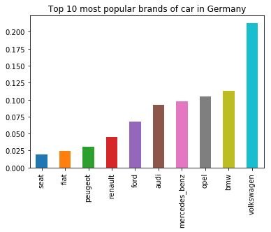

```python
brand_counts.head(10).sort_values().plot(kind='bar', title='Top 10 most popular brands of car in Germany')
```

**Analysis**

> - Volkswagen is the most polular choice, counting more than 20% of the market
> - BMW, Opel, mercedes_benz and audi are the next popular one, but far from volkswagen's popularity

```python
# Select the brands that are more than 5% of the market to analyze
common_brands=brand_counts[brand_counts > .05].index
common_brands
```

```
Index(['volkswagen', 'bmw', 'opel', 'mercedes_benz', 'audi', 'ford'], dtype='object')
```

```python
#Analyze the common brands and its average price
brand_mean_prices = {}

for brand in common_brands:
    brand_only = autos[autos["brand"] == brand]
    mean_price = brand_only["price"].mean()
    brand_mean_prices[brand] = int(mean_price)

brand_mean_prices
```

```
{'volkswagen': 5688,
 'bmw': 8680,
 'opel': 3176,
 'mercedes_benz': 8664,
 'audi': 9381,
 'ford': 3942}
```

```python
# Convert the dictionary to a pandas series and sort its value
mean_prices=pd.Series(brand_mean_prices).sort_values(ascending=False)
mean_prices
```

```
audi             9381
bmw              8680
mercedes_benz    8664
volkswagen       5688
ford             3942
opel             3176
dtype: int64
```

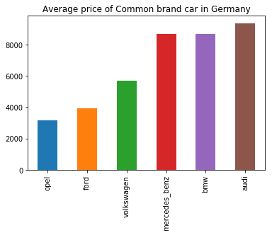

```python
mean_prices.sort_values().plot(kind='bar', title='Average price of Common brand car in Germany')
```

### Question 2: Among common brands, are there large differences on kilometer that can affect listing price?

```python
#Analyze the common brands and its average odometer_km
brand_mean_km = {}

for brand in common_brands:
    brand_only = autos[autos["brand"] == brand]
    mean_km = brand_only["kilometer"].mean()
    brand_mean_km[brand] = int(mean_km)

brand_mean_km
```

```
{'volkswagen': 128117,
 'bmw': 132985,
 'opel': 128378,
 'mercedes_benz': 130802,
 'audi': 129142,
 'ford': 123575}
```

```python
# Convert the dictionary to a pandas series
mean_km=pd.Series(brand_mean_km)
```

```python
# Convert pandas series to a data frame
common_brand_info=pd.DataFrame(mean_prices, columns=['mean_price'])
```

```python
# Add the 'mean_km' to the data frame
common_brand_info['mean_km']=mean_km
common_brand_info
```

|  | mean_price | mean_km |
| --- | --- | --- |
| audi | 9381 | 129142 |
| bmw | 8680 | 132985 |
| mercedes_benz | 8664 | 130802 |
| volkswagen | 5688 | 128117 |
| ford | 3942 | 123575 |
| opel | 3176 | 128378 |

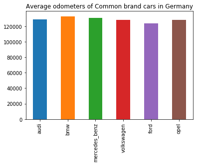

```python
common_brand_info['mean_km'].plot(kind='bar', title='Average odometers of Common brand cars in Germany')
```

### Answer 2:

> - Among these common brands of cars on sale, the average of odometers are all ablove 100000km; The range of car mileages does not vary as much as the prices do by brand.

### Alternative ways to answering Questions 1&2

```python
brand_counts=autos['brand'].value_counts(normalize=True)
brand_counts.head(10)
```

```
volkswagen       0.213195
bmw              0.113370
opel             0.104488
mercedes_benz    0.097239
audi             0.092348
ford             0.067423
renault          0.044789
peugeot          0.030254
fiat             0.024698
seat             0.019178
Name: brand, dtype: float64
```

```python
common_brands=brand_counts[brand_counts > .05].index
common_brands
```

```
Index(['volkswagen', 'bmw', 'opel', 'mercedes_benz', 'audi', 'ford'], dtype='object')
```

```python
# using query methods to select commom brands
autos_common_brands=autos.query('brand in ["volkswagen", "bmw", "opel", "mercedes_benz", "audi", "ford"]')
autos_common_brands.head(2)
```

|  | name | price | vehicle_type | registration_year | gearbox | power_ps | model | kilometer | fuel_type | brand | unrepaired_damage |
| --- | --- | --- | --- | --- | --- | --- | --- | --- | --- | --- | --- |
| 1 | A5_Sportback_2.7_Tdi | 18300 | coupe | 2011 | manual | 190 | NaN | 125000 | diesel | audi | yes |
| 3 | GOLF_4_1_4__3TÜRER | 1500 | kleinwagen | 2001 | manual | 75 | golf | 150000 | benzin | volkswagen | no |

```python
common_brands_info=autos_common_brands.groupby('brand').mean()[['price','kilometer']]
common_brands_info
```

| brand | price | kilometer |
| --- | --- | --- |
| audi | 9381.733959 | 129142.771804 |
| bmw | 8680.722063 | 132985.029769 |
| ford | 3942.425567 | 123575.588391 |
| mercedes_benz | 8664.469681 | 130802.603037 |
| opel | 3176.230069 | 128378.365788 |
| volkswagen | 5688.166885 | 128117.827027 |

### Question 3: What are the factors that affect car price?

### Q3_Step1: First we will analyze the columns with numerical value and see how it is correlated with the car price using correlation heatmap and scatter chart.

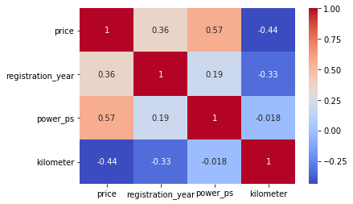

```python
# plot correlation heatmap
sns.heatmap(autos.corr(),annot=True,cmap='coolwarm')
```

**Analysis**

> - Prices are positively correlated with power_ps and registration_year. Power_ps has stronger correlation.
> - Prices are negatively correlated with kilometer.

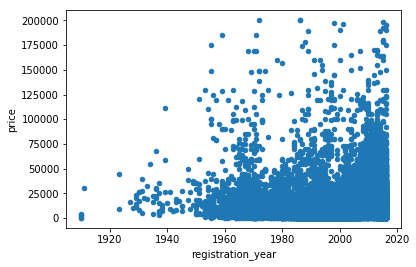

```python
# plot scatter chart to check the relation between 'registration_year' and 'price'
autos.plot(kind='scatter', x='registration_year', y='price')
```

**Analysis**

> - In general, the newer the cars, the higher the prices, but for a given registration year, there are still huge gap on prices

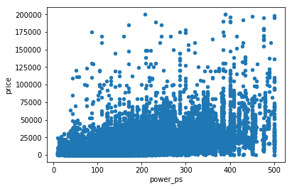

```python
# plot scatter chart to check the relation between 'power_ps' and 'price'
autos.plot(kind='scatter', x='power_ps', y='price')
```

**Analysis**

> - Most cars have pow_ps under 400, and in general the higher the power_ps, the higher the price; but there are cars with extremely high power_ps, but prices range is still very large.

### Q3_Step2: We will analyze the columns with catergorical string values using bar chart.

**1.'vehicle_type'**

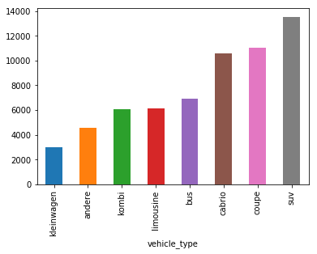

```python
type_price=autos.groupby('vehicle_type').mean()['price']
type_price.sort_values().plot(kind='bar')
```

**Analyze**

> - As we can see, suv is the most expensive ones, and kleinwagen the lease expensive.

**2.'gearbox'**

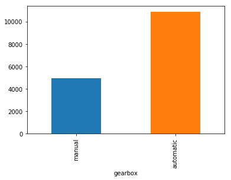

```python
# Analyze whether the damege is repaired can positively influnce the price
gearbox_price=autos.groupby('gearbox')['price'].mean()
gearbox_price.sort_values().plot(kind='bar')
```

**Analysis**

> - In general, automatic cars are more expensive

**3.'fuel_type'**

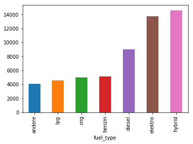

```python
fuel_price=autos.groupby('fuel_type').mean()['price']
fuel_price.sort_values().plot(kind='bar')
```

**Analysis**

**4.'unrepaired_damage'**

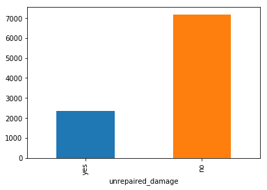

```python
# Analyze whether the damege is repaired can positively influnce the price
unrepaired_price=autos.groupby('unrepaired_damage')['price'].mean()
unrepaired_price.sort_values().plot(kind='bar')
```

**Analysis**

> - In general, when the demage is repaired, the car prices are higher

**5.'brand'**

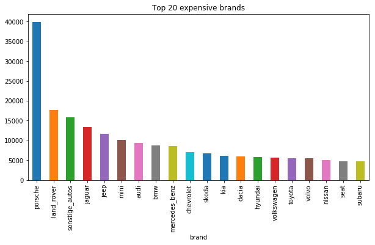

```python
top_20_expensive=autos.groupby('brand').mean().sort_values('price',ascending=False).head(20)
top_20_expensive['price'].plot(kind='bar',title='Top 20 expensive brands', figsize=(10, 5))
```

**Analysis**

> - Porsche is the most expensive brand, the average price double the following competitor 'land_rover'. 'sonstige_autos' means brand is unknown and we can furthur investigate this catergory.
> - The top 6 most expensive brands are all not the most common brands. The most popular brand volkswagen has very affordable average price.

### Q3_Step4: Let's analyze the most popular brand 'volkswagen', and see how car model and name can affect prices

```python
# Selet the rows that are volkswagen for analyze
volkswagen=autos[autos['brand']=='volkswagen']
volkswagen.describe(include='all')
```

|  | name | price | vehicle_type | registration_year | gearbox | power_ps | model | kilometer | fuel_type | brand | unrepaired_damage |
| --- | --- | --- | --- | --- | --- | --- | --- | --- | --- | --- | --- |
| count | 65698 | 65698.000000 | 62552 | 65698.000000 | 64564 | 65698.000000 | 63665 | 65698.000000 | 62156 | 65698 | 55382 |
| unique | 40985 | NaN | 8 | NaN | 2 | NaN | 22 | NaN | 7 | 1 | 2 |
| top | Volkswagen_Golf_1.4 | NaN | limousine | NaN | manual | NaN | golf | NaN | benzin | volkswagen | no |
| freq | 573 | NaN | 18529 | NaN | 55398 | NaN | 25147 | NaN | 37641 | 65698 | 49797 |
| mean | NaN | 5688.166885 | NaN | 2002.711148 | NaN | 106.265746 | NaN | 128117.827027 | NaN | NaN | NaN |
| std | NaN | 6409.844585 | NaN | 7.110533 | NaN | 45.209319 | NaN | 38422.095700 | NaN | NaN | NaN |
| min | NaN | 100.000000 | NaN | 1910.000000 | NaN | 10.000000 | NaN | 5000.000000 | NaN | NaN | NaN |
| 25% | NaN | 1400.000000 | NaN | 1998.000000 | NaN | 75.000000 | NaN | 125000.000000 | NaN | NaN | NaN |
| 50% | NaN | 3333.000000 | NaN | 2003.000000 | NaN | 101.000000 | NaN | 150000.000000 | NaN | NaN | NaN |
| 75% | NaN | 7800.000000 | NaN | 2008.000000 | NaN | 131.000000 | NaN | 150000.000000 | NaN | NaN | NaN |
| max | NaN | 123456.000000 | NaN | 2016.000000 | NaN | 500.000000 | NaN | 150000.000000 | NaN | NaN | NaN |

```python
# Add a new columns for the name length
volkswagen['name_length']=volkswagen['name'].apply(len)
volkswagen[['price','name_length']].corr()
```

|  | price | name_length |
| --- | --- | --- |
| price | 1.00000 | 0.29155 |
| name_length | 0.29155 | 1.00000 |

**Analysis**

> - name_lenth is positively correlated with price, as the longer the name is, the more features are added, so the price is higher, but the correlation is not strong.

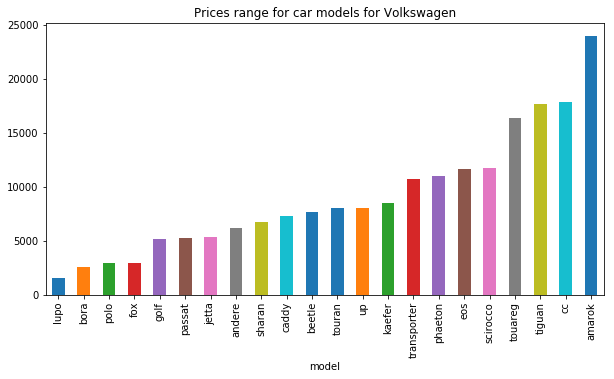

```python
model_price=volkswagen.groupby('model')['price'].mean()
model_price.sort_values().plot(kind='bar',figsize=(10,5), title='Prices range for car models for Volkswagen')
```

**Analysis**

> - There are huge price gap on different car model. For volkswagen, amorok is the most expensive ones, and lupo the least expensive one.
> - I have done the same analysis for other factors for volkswagen, and results are consistant compared with the whole dataset analysis.

### Answer 3:

> - From the correlation heatmap and scatter chart, we can conclude price are positively correlated with power_ps and registration_year and are negatively correlated with kilometer in general, but power_ps is has stronger influence.
> - The other strong catagorical factors that affect the car price are the brand and whether the damage is repaired or not; Also automic are much mroe expensive than manual
> - vehicle_type and fuel_type have strong effects too
> - By analyzing data for volkswagen, we can see the above conclusions are consistent for specific car brand. And for the same brand, different model have high price ranges.